# Description of Data:

**these are the columns that the data set contain :**

**Model** – vehicle make and model

**Displ** – engine displacement in liters

**Cyl** – number of engine cylinders

**Trans** – transmission type plus number of gears :

```
    1 - Auto - Automatic

    2 - Man - Manual

    3 - SemiAuto - Semi-Automatic

    4 - SCV - Selectable Continuously Variable (e.g. CVT with paddles)

    5 - AutoMan - Automated Manual

    6 - AMS - Automated Manual-Selectable (e.g. Automated Manual with paddles)

    7 - Other - Other

    8 - CVT - Continuously Variable

    9 - CM3 - Creeper/Manual 3-Speed

    10 - CM4 - Creeper/Manual 4-Speed

    11 - C4 - Creeper/Manual 4-Speed

    12 - C5 - Creeper/Manual 5-Speed

    13 - Auto-S2 - Semi-Automatic 2-Speed

    14 - Auto-S3 - Semi-Automatic 3-Speed

    15 - Auto-S4 - Semi-Automatic 4-Speed

    16 - Auto-S5 - Semi-Automatic 5-Speed

    17 -Auto-S6 - Semi-Automatic 6-Speed

    18 - Auto-S7 - Semi-Automatic 7-Speed
```

**Drive** – 2-wheel Drive, 4-wheel drive/all-wheel drive

**Fuel** – fuel(s)

##### Cert Region :**

```
    1- CA - California
    2- CE - Calif. + NLEV (Northeast trading area)
    3- CF - Clean Fuel Vehicle
    4- CL - Calif. + NLEV (All states)
    5- FA - Federal All Altitude
    6- FC - Tier 2 Federal and Calif.
    7- NF - CFV + NLEV(ASTR) + Calif.
    8- NL - NLEV (All states)
```

**Stnd** – vehicle emissions standard code.

**Stnd Description** – vehicle emissions standard description. **--> for info :** https://www.epa.gov/greenvehicles/federal-and-california-light-duty-vehicle-emissions-standards-airpollutants

**Underhood ID** – engine family or test group ID. **--> for info :** http://www.fueleconomy.gov/feg/findacarhelp.shtml#airPollutionScore

**Veh Class** – EPA vehicle class. **--> for info :** http://www.fueleconomy.gov/feg/findacarhelp.shtml#epaSizeClass

**Air Pollution Score (Smog Rating).** **--> for info** http://www.fueleconomy.gov/feg/findacarhelp.shtml#airPollutionScore and https://www.epa.gov/greenvehicles/smog-rating

**City MPG** – city fuel economy in miles per gallon

**Hwy MPG** – highway fuel economy in miles per gallon

**Cmb MPG** – combined city/highway fuel economy in miles per gallon

**Greenhouse Gas Score (Greenhouse Gas Rating)** **--> for info :** https://www.epa.gov/greenvehicles/greenhouse-gas-rating

**SmartWay** – Yes, No, or Elite. **--> for info :** https://www.epa.gov/greenvehicles/consider-smartwayvehicle

**Comb CO2** – combined city/highway CO2 tailpipe emissions in grams per mile

- investigating the datasets
- wrangling data
- Exploring with Visuals

```python
import pandas as pd
import numpy as np
import matplotlib.pyplot as plt
import seaborn as sns
import re
np.set_printoptions(suppress = True,linewidth=100,precision=2)
```

## investigating the datasets:

```
number of samples in each dataset
number of columns in each dataset
duplicate rows in each dataset
datatypes of columns
features with missing values
number of non-null unique values for features in each dataset
what those unique values are and counts for each
```

```python
df08 = pd.read_csv("C:/Users/mantabanta/Desktop/fuel_economy/fuel_economy_datasets/all_alpha_08.csv",delimiter=",")
df18 = pd.read_csv("C:/Users/mantabanta/Desktop/fuel_economy/fuel_economy_datasets/all_alpha_18.csv",delimiter=";")
```

```python
# at first will start with 2008 data set
df08.head()
```

|  | Model | Displ | Cyl | Trans | Drive | Fuel | Sales Area | Stnd | Underhood ID | Veh Class | Air Pollution Score | FE Calc Appr | City MPG | Hwy MPG | Cmb MPG | Unadj Cmb MPG | Greenhouse Gas Score | SmartWay |
| --- | --- | --- | --- | --- | --- | --- | --- | --- | --- | --- | --- | --- | --- | --- | --- | --- | --- | --- |
| 0 | ACURA MDX | 3.7 | (6 cyl) | Auto-S5 | 4WD | Gasoline | CA | U2 | 8HNXT03.7PKR | SUV | 7 | Drv | 15 | 20 | 17 | 22.0527 | 4 | no |
| 1 | ACURA MDX | 3.7 | (6 cyl) | Auto-S5 | 4WD | Gasoline | FA | B5 | 8HNXT03.7PKR | SUV | 6 | Drv | 15 | 20 | 17 | 22.0527 | 4 | no |
| 2 | ACURA RDX | 2.3 | (4 cyl) | Auto-S5 | 4WD | Gasoline | CA | U2 | 8HNXT02.3DKR | SUV | 7 | Drv | 17 | 22 | 19 | 24.1745 | 5 | no |
| 3 | ACURA RDX | 2.3 | (4 cyl) | Auto-S5 | 4WD | Gasoline | FA | B5 | 8HNXT02.3DKR | SUV | 6 | Drv | 17 | 22 | 19 | 24.1745 | 5 | no |
| 4 | ACURA RL | 3.5 | (6 cyl) | Auto-S5 | 4WD | Gasoline | CA | U2 | 8HNXV03.5HKR | midsize car | 7 | Drv | 16 | 24 | 19 | 24.5629 | 5 | no |

```python
df08.describe()
```

|  | Displ | Unadj Cmb MPG |
| --- | --- | --- |
| count | 2404.000000 | 2205.000000 |
| mean | 3.748918 | 23.916104 |
| std | 1.335785 | 6.366170 |
| min | 1.300000 | 10.018400 |
| 25% | 2.500000 | 19.113900 |
| 50% | 3.500000 | 23.921300 |
| 75% | 4.800000 | 27.869300 |
| max | 8.400000 | 65.777800 |

```python
df08.shape
```

```
(2404, 18)
```

we 've 2404 rows(samples) and 18 columns(features)

```python
df08.duplicated().sum()
```

```
25
```

```python
df08.info()
```

```
<class 'pandas.core.frame.DataFrame'>
RangeIndex: 2404 entries, 0 to 2403
Data columns (total 18 columns):
 #   Column                Non-Null Count  Dtype
---  ------                --------------  -----
 0   Model                 2404 non-null   object
 1   Displ                 2404 non-null   float64
 2   Cyl                   2205 non-null   object
 3   Trans                 2205 non-null   object
 4   Drive                 2311 non-null   object
 5   Fuel                  2404 non-null   object
 6   Sales Area            2404 non-null   object
 7   Stnd                  2404 non-null   object
 8   Underhood ID          2404 non-null   object
 9   Veh Class             2404 non-null   object
 10  Air Pollution Score   2404 non-null   object
 11  FE Calc Appr          2205 non-null   object
 12  City MPG              2205 non-null   object
 13  Hwy MPG               2205 non-null   object
 14  Cmb MPG               2205 non-null   object
 15  Unadj Cmb MPG         2205 non-null   float64
 16  Greenhouse Gas Score  2205 non-null   object
 17  SmartWay              2404 non-null   object
dtypes: float64(2), object(16)
memory usage: 338.2+ KB
```

```python
df08.isna().sum()
```

```
Model                     0
Displ                     0
Cyl                     199
Trans                   199
Drive                    93
Fuel                      0
Sales Area                0
Stnd                      0
Underhood ID              0
Veh Class                 0
Air Pollution Score       0
FE Calc Appr            199
City MPG                199
Hwy MPG                 199
Cmb MPG                 199
Unadj Cmb MPG           199
Greenhouse Gas Score    199
SmartWay                  0
dtype: int64
```

##### there is a lot of missing data here

```python
df08.nunique()
```

```
Model                   436
Displ                    47
Cyl                       8
Trans                    14
Drive                     2
Fuel                      5
Sales Area                3
Stnd                     12
Underhood ID            343
Veh Class                 9
Air Pollution Score      13
FE Calc Appr              2
City MPG                 39
Hwy MPG                  43
Cmb MPG                  38
Unadj Cmb MPG           721
Greenhouse Gas Score     20
SmartWay                  2
dtype: int64
```

```python
df08.nunique
```

[output not shown]

[output cut: 25 more lines]

```python
# now for 2018 dataset
df18.head()
```

|  | Model | Displ | Cyl | Trans | Drive | Fuel | Cert Region | Stnd | Stnd Description | Underhood ID | Veh Class | Air Pollution Score | City MPG | Hwy MPG | Cmb MPG | Greenhouse Gas Score | SmartWay | Comb CO2 |
| --- | --- | --- | --- | --- | --- | --- | --- | --- | --- | --- | --- | --- | --- | --- | --- | --- | --- | --- |
| 0 | ACURA RDX | 3.5 | 6.0 | SemiAuto-6 | 2WD | Gasoline | FA | T3B125 | Federal Tier 3 Bin 125 | JHNXT03.5GV3 | small SUV | 3 | 20 | 28 | 23 | 5 | No | 386 |
| 1 | ACURA RDX | 3.5 | 6.0 | SemiAuto-6 | 2WD | Gasoline | CA | U2 | California LEV-II ULEV | JHNXT03.5GV3 | small SUV | 3 | 20 | 28 | 23 | 5 | No | 386 |
| 2 | ACURA RDX | 3.5 | 6.0 | SemiAuto-6 | 4WD | Gasoline | FA | T3B125 | Federal Tier 3 Bin 125 | JHNXT03.5GV3 | small SUV | 3 | 19 | 27 | 22 | 4 | No | 402 |
| 3 | ACURA RDX | 3.5 | 6.0 | SemiAuto-6 | 4WD | Gasoline | CA | U2 | California LEV-II ULEV | JHNXT03.5GV3 | small SUV | 3 | 19 | 27 | 22 | 4 | No | 402 |
| 4 | ACURA TLX | 2.4 | 4.0 | AMS-8 | 2WD | Gasoline | CA | L3ULEV125 | California LEV-III ULEV125 | JHNXV02.4WH3 | small car | 3 | 23 | 33 | 27 | 6 | No | 330 |

```python
df18.describe()
```

|  | Displ | Cyl | Air Pollution Score | Greenhouse Gas Score |
| --- | --- | --- | --- | --- |
| count | 1609.000000 | 1609.000000 | 1611.000000 | 1611.000000 |
| mean | 3.055687 | 5.479180 | 3.958411 | 4.711359 |
| std | 1.344574 | 1.749121 | 1.824303 | 1.657429 |
| min | 1.200000 | 3.000000 | 1.000000 | 1.000000 |
| 25% | 2.000000 | 4.000000 | 3.000000 | 4.000000 |
| 50% | 3.000000 | 6.000000 | 3.000000 | 5.000000 |
| 75% | 3.600000 | 6.000000 | 5.000000 | 6.000000 |
| max | 8.000000 | 16.000000 | 10.000000 | 10.000000 |

```python
df18.shape
```

```
(1611, 18)
```

##### we 've 1611 rows(samples) and 18 columns(features)

```python
df18.duplicated().sum()
```

```
0
```

```python
df18.info()
```

```
<class 'pandas.core.frame.DataFrame'>
RangeIndex: 1611 entries, 0 to 1610
Data columns (total 18 columns):
 #   Column                Non-Null Count  Dtype
---  ------                --------------  -----
 0   Model                 1611 non-null   object
 1   Displ                 1609 non-null   float64
 2   Cyl                   1609 non-null   float64
 3   Trans                 1611 non-null   object
 4   Drive                 1611 non-null   object
 5   Fuel                  1611 non-null   object
 6   Cert Region           1611 non-null   object
 7   Stnd                  1611 non-null   object
 8   Stnd Description      1611 non-null   object
 9   Underhood ID          1611 non-null   object
 10  Veh Class             1611 non-null   object
 11  Air Pollution Score   1611 non-null   int64
 12  City MPG              1611 non-null   object
 13  Hwy MPG               1611 non-null   object
 14  Cmb MPG               1611 non-null   object
 15  Greenhouse Gas Score  1611 non-null   int64
 16  SmartWay              1611 non-null   object
 17  Comb CO2              1611 non-null   object
dtypes: float64(2), int64(2), object(14)
memory usage: 226.7+ KB
```

```python
df18.isna().sum()
```

```
Model                   0
Displ                   2
Cyl                     2
Trans                   0
Drive                   0
Fuel                    0
Cert Region             0
Stnd                    0
Stnd Description        0
Underhood ID            0
Veh Class               0
Air Pollution Score     0
City MPG                0
Hwy MPG                 0
Cmb MPG                 0
Greenhouse Gas Score    0
SmartWay                0
Comb CO2                0
dtype: int64
```

##### the info shows that 2 columns have missing data (Displ , Cyl)

```python
df08.nunique()
```

```
Model                   436
Displ                    47
Cyl                       8
Trans                    14
Drive                     2
Fuel                      5
Sales Area                3
Stnd                     12
Underhood ID            343
Veh Class                 9
Air Pollution Score      13
FE Calc Appr              2
City MPG                 39
Hwy MPG                  43
Cmb MPG                  38
Unadj Cmb MPG           721
Greenhouse Gas Score     20
SmartWay                  2
dtype: int64
```

```python
df18.nunique
```

[output not shown]

[output cut: 38 more lines]

# wrangling data

- dropping non useful features
- renaming features
- missing data
- duplicated data
- Fixing Data Types
- filtering data

## Drop Extraneous Columns

By looking at the description of the features, there are some features that are of no use to us

So let's define them and remove 'em from both datasets

# ___> From 2008 dataset: 'Stnd', 'Underhood ID', 'FE Calc Appr', 'Unadj Cmb MPG'

# ___> From 2018 dataset: 'Stnd', 'Stnd Description', 'Underhood ID', 'Comb CO2'

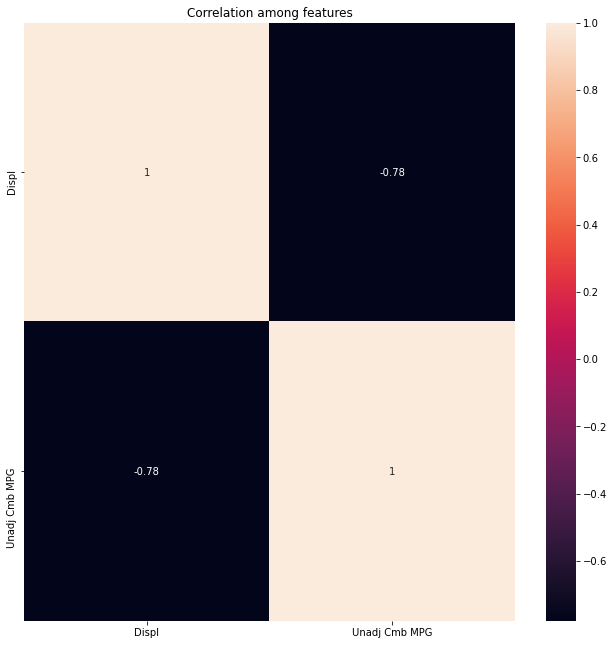

```python
# if u might ask why i don't use a heat map to show the relations and choose the weakest features ,
# here is why
# heat map for 2008
Correlation_Matrix = df08.corr()
f, ax = plt.subplots(figsize=(11, 11))
sns.heatmap(Correlation_Matrix,annot=True)
plt.title('Correlation among features');
plt.show()
```

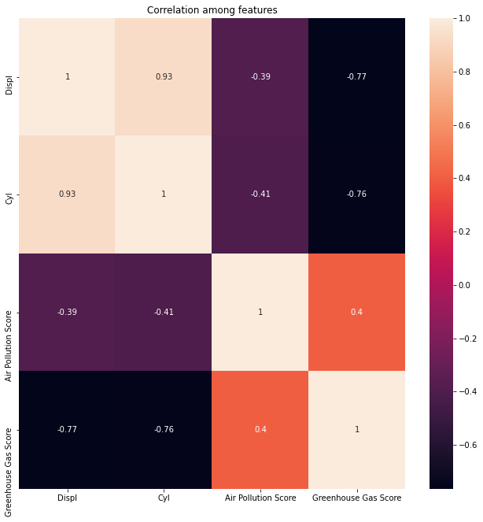

```python
# heat map for 2018
# for 2008
Correlation_Matrix = df18.corr()
f, ax = plt.subplots(figsize=(11, 11))
sns.heatmap(Correlation_Matrix,annot=True)
plt.title('Correlation among features');
plt.show()
```

as shown above the columns needs a lot of work so the corr() won't be useful here so a manual search 'd be better . i coul've removed these features after the wrangling process but i like cars so 'll just do it manually (an execuse for reading xd xd xd )

```python
# drop columns from 2008 dataset
df08.drop(['Stnd', 'Underhood ID', 'FE Calc Appr', 'Unadj Cmb MPG'], axis=1, inplace=True)

# confirm changes
df08.columns
```

```
Index(['Model', 'Displ', 'Cyl', 'Trans', 'Drive', 'Fuel', 'Sales Area',
       'Veh Class', 'Air Pollution Score', 'City MPG', 'Hwy MPG', 'Cmb MPG',
       'Greenhouse Gas Score', 'SmartWay'],
      dtype='object')
```

```python
# drop columns from 2018 dataset
df18.drop(['Stnd', 'Stnd Description', 'Underhood ID', 'Comb CO2'], axis=1, inplace=True)

# confirm changes
df18.columns
```

```
Index(['Model', 'Displ', 'Cyl', 'Trans', 'Drive', 'Fuel', 'Cert Region',
       'Veh Class', 'Air Pollution Score', 'City MPG', 'Hwy MPG', 'Cmb MPG',
       'Greenhouse Gas Score', 'SmartWay'],
      dtype='object')
```

# Rename features

```python
# Change the "Sales Area" column label in the 2008 dataset only to "Cert Region" for consistency ,
# since it's "Cert Region" in 2018 dataset .

# Rename all column labels to replace spaces with underscores and convert everything to lowercase.
```

```python
# rename Sales Area to Cert Region
df08.rename({"Sales Area":"cert region"},axis=1,inplace=True)

# confirm changes
df08.head(1)
```

|  | Model | Displ | Cyl | Trans | Drive | Fuel | cert region | Veh Class | Air Pollution Score | City MPG | Hwy MPG | Cmb MPG | Greenhouse Gas Score | SmartWay |
| --- | --- | --- | --- | --- | --- | --- | --- | --- | --- | --- | --- | --- | --- | --- |
| 0 | ACURA MDX | 3.7 | (6 cyl) | Auto-S5 | 4WD | Gasoline | CA | SUV | 7 | 15 | 20 | 17 | 4 | no |

```python
# replace spaces with underscores and lowercase labels for 2008 dataset
df08.rename(columns=lambda x: x.strip().lower().replace(" ", "_"), inplace=True)

# confirm changes
df08.columns
```

```
Index(['model', 'displ', 'cyl', 'trans', 'drive', 'fuel', 'cert_region',
       'veh_class', 'air_pollution_score', 'city_mpg', 'hwy_mpg', 'cmb_mpg',
       'greenhouse_gas_score', 'smartway'],
      dtype='object')
```

```python
# replace spaces with underscores and lowercase labels for 2018 dataset
df18.rename(columns=lambda x:x.strip().lower().replace(" ","_"),inplace=True)

# confirm changes
df18.columns
```

```
Index(['model', 'displ', 'cyl', 'trans', 'drive', 'fuel', 'cert_region',
       'veh_class', 'air_pollution_score', 'city_mpg', 'hwy_mpg', 'cmb_mpg',
       'greenhouse_gas_score', 'smartway'],
      dtype='object')
```

```python
# make sure they're all identical like this
(df08.columns == df18.columns).all()
```

```
True
```

# missing data

```python
df08.isna().sum()
```

```
model                     0
displ                     0
cyl                     199
trans                   199
drive                    93
fuel                      0
cert_region               0
veh_class                 0
air_pollution_score       0
city_mpg                199
hwy_mpg                 199
cmb_mpg                 199
greenhouse_gas_score    199
smartway                  0
dtype: int64
```

```python
# let's take a look at some columns with missing data for Curiosity . let's say cmb_mpg &  cyl
df08[df08.cmb_mpg.isna()]
```

|  | model | displ | cyl | trans | drive | fuel | cert_region | veh_class | air_pollution_score | city_mpg | hwy_mpg | cmb_mpg | greenhouse_gas_score | smartway |
| --- | --- | --- | --- | --- | --- | --- | --- | --- | --- | --- | --- | --- | --- | --- |
| 389 | CHEVROLET Express 3500 | 6.0 | NaN | NaN | NaN | Gasoline | FC | van | 3 | NaN | NaN | NaN | NaN | no |
| 390 | CHEVROLET Express 3500 | 6.2 | NaN | NaN | NaN | Gasoline | FC | van | 3 | NaN | NaN | NaN | NaN | no |
| 391 | CHEVROLET Express 3500 | 4.8 | NaN | NaN | NaN | Gasoline | FA | van | 2 | NaN | NaN | NaN | NaN | no |
| 392 | CHEVROLET Express 3500 | 4.8 | NaN | NaN | NaN | Gasoline | FA | van | 2 | NaN | NaN | NaN | NaN | no |
| 393 | CHEVROLET Express 3500 | 4.8 | NaN | NaN | NaN | Gasoline | CA | van | 2 | NaN | NaN | NaN | NaN | no |
| ... | ... | ... | ... | ... | ... | ... | ... | ... | ... | ... | ... | ... | ... | ... |
| 1465 | LINCOLN Navigator | 5.4 | NaN | NaN | 4WD | Gasoline | FA | SUV | 6 | NaN | NaN | NaN | NaN | no |
| 1934 | PORSCHE Cayenne GTS | 4.8 | NaN | NaN | 4WD | Gasoline | CA | SUV | 7 | NaN | NaN | NaN | NaN | no |
| 1935 | PORSCHE Cayenne GTS | 4.8 | NaN | NaN | 4WD | Gasoline | FA | SUV | 6 | NaN | NaN | NaN | NaN | no |
| 1939 | PORSCHE Cayenne Turbo | 4.8 | NaN | NaN | 4WD | Gasoline | FA | SUV | 6 | NaN | NaN | NaN | NaN | no |
| 1941 | PORSCHE Cayenne Turbo | 4.8 | NaN | NaN | 4WD | Gasoline | CA | SUV | 6 | NaN | NaN | NaN | NaN | no |

199 rows × 14 columns

```python
# now for cyl column
df08[df08.cyl.isna()]
```

|  | model | displ | cyl | trans | drive | fuel | cert_region | veh_class | air_pollution_score | city_mpg | hwy_mpg | cmb_mpg | greenhouse_gas_score | smartway |
| --- | --- | --- | --- | --- | --- | --- | --- | --- | --- | --- | --- | --- | --- | --- |
| 389 | CHEVROLET Express 3500 | 6.0 | NaN | NaN | NaN | Gasoline | FC | van | 3 | NaN | NaN | NaN | NaN | no |
| 390 | CHEVROLET Express 3500 | 6.2 | NaN | NaN | NaN | Gasoline | FC | van | 3 | NaN | NaN | NaN | NaN | no |
| 391 | CHEVROLET Express 3500 | 4.8 | NaN | NaN | NaN | Gasoline | FA | van | 2 | NaN | NaN | NaN | NaN | no |
| 392 | CHEVROLET Express 3500 | 4.8 | NaN | NaN | NaN | Gasoline | FA | van | 2 | NaN | NaN | NaN | NaN | no |
| 393 | CHEVROLET Express 3500 | 4.8 | NaN | NaN | NaN | Gasoline | CA | van | 2 | NaN | NaN | NaN | NaN | no |
| ... | ... | ... | ... | ... | ... | ... | ... | ... | ... | ... | ... | ... | ... | ... |
| 1465 | LINCOLN Navigator | 5.4 | NaN | NaN | 4WD | Gasoline | FA | SUV | 6 | NaN | NaN | NaN | NaN | no |
| 1934 | PORSCHE Cayenne GTS | 4.8 | NaN | NaN | 4WD | Gasoline | CA | SUV | 7 | NaN | NaN | NaN | NaN | no |
| 1935 | PORSCHE Cayenne GTS | 4.8 | NaN | NaN | 4WD | Gasoline | FA | SUV | 6 | NaN | NaN | NaN | NaN | no |
| 1939 | PORSCHE Cayenne Turbo | 4.8 | NaN | NaN | 4WD | Gasoline | FA | SUV | 6 | NaN | NaN | NaN | NaN | no |
| 1941 | PORSCHE Cayenne Turbo | 4.8 | NaN | NaN | 4WD | Gasoline | CA | SUV | 6 | NaN | NaN | NaN | NaN | no |

199 rows × 14 columns

```python
# let's drop the missing data for 2008 dataset
df08.dropna(inplace=True)
```

```python
# now  for 2018 dataset cyl & displ
df18.isna().sum()
```

```
model                   0
displ                   2
cyl                     2
trans                   0
drive                   0
fuel                    0
cert_region             0
veh_class               0
air_pollution_score     0
city_mpg                0
hwy_mpg                 0
cmb_mpg                 0
greenhouse_gas_score    0
smartway                0
dtype: int64
```

```python
# let's look at 'em
df18[df18.cyl.isna()]
```

|  | model | displ | cyl | trans | drive | fuel | cert_region | veh_class | air_pollution_score | city_mpg | hwy_mpg | cmb_mpg | greenhouse_gas_score | smartway |
| --- | --- | --- | --- | --- | --- | --- | --- | --- | --- | --- | --- | --- | --- | --- |
| 996 | KIA Soul Electric | NaN | NaN | Auto-1 | 2WD | Electricity | FA | station wagon | 10 | 124 | 93 | 108 | 10 | Elite |
| 997 | KIA Soul Electric | NaN | NaN | Auto-1 | 2WD | Electricity | CA | station wagon | 10 | 124 | 93 | 108 | 10 | Elite |

```python
# let's check if maybe we can fill the missing data for 2018 dataset
# will check all the data for the KIA Soul Electric model and see the results
df18.query("model == 'KIA Soul Electric'")
```

|  | model | displ | cyl | trans | drive | fuel | cert_region | veh_class | air_pollution_score | city_mpg | hwy_mpg | cmb_mpg | greenhouse_gas_score | smartway |
| --- | --- | --- | --- | --- | --- | --- | --- | --- | --- | --- | --- | --- | --- | --- |
| 996 | KIA Soul Electric | NaN | NaN | Auto-1 | 2WD | Electricity | FA | station wagon | 10 | 124 | 93 | 108 | 10 | Elite |
| 997 | KIA Soul Electric | NaN | NaN | Auto-1 | 2WD | Electricity | CA | station wagon | 10 | 124 | 93 | 108 | 10 | Elite |

#### sadly the KIA model certified only once in FA & CA and both are the ones that contains missing data :(

```python
# now let's drop the missing data for 2018 too
df18.dropna(inplace=True)
```

# Drop duplicated

```python
# let's check for both ifles
df08.duplicated().sum()
```

```
63
```

```python
df18.duplicated().sum()
```

```
5
```

```python
# let's look at both file duplicated data

df08.loc[df08.duplicated(keep=False),:]
```

|  | model | displ | cyl | trans | drive | fuel | cert_region | veh_class | air_pollution_score | city_mpg | hwy_mpg | cmb_mpg | greenhouse_gas_score | smartway |
| --- | --- | --- | --- | --- | --- | --- | --- | --- | --- | --- | --- | --- | --- | --- |
| 120 | BMW 328ci | 3.0 | (6 cyl) | Man-6 | 2WD | Gasoline | FA | small car | 6 | 20 | 30 | 24 | 7 | yes |
| 121 | BMW 328ci | 3.0 | (6 cyl) | Man-6 | 2WD | Gasoline | FA | small car | 6 | 20 | 30 | 24 | 7 | yes |
| 122 | BMW 328ci | 3.0 | (6 cyl) | Auto-S6 | 2WD | Gasoline | FA | small car | 6 | 23 | 31 | 25 | 7 | yes |
| 123 | BMW 328ci | 3.0 | (6 cyl) | Auto-S6 | 2WD | Gasoline | FA | small car | 6 | 23 | 31 | 25 | 7 | yes |
| 128 | BMW 328ci Convertible | 3.0 | (6 cyl) | Man-6 | 2WD | Gasoline | FA | small car | 6 | 19 | 29 | 22 | 6 | no |
| ... | ... | ... | ... | ... | ... | ... | ... | ... | ... | ... | ... | ... | ... | ... |
| 2232 | TOYOTA Tacoma | 2.7 | (4 cyl) | Man-5 | 2WD | Gasoline | FA | pickup | 6 | 20 | 25 | 22 | 6 | no |
| 2234 | TOYOTA Tacoma | 2.7 | (4 cyl) | Auto-L4 | 2WD | Gasoline | CA | pickup | 6 | 19 | 25 | 21 | 6 | no |
| 2235 | TOYOTA Tacoma | 2.7 | (4 cyl) | Man-5 | 2WD | Gasoline | CA | pickup | 6 | 20 | 25 | 22 | 6 | no |
| 2236 | TOYOTA Tacoma | 2.7 | (4 cyl) | Auto-L4 | 2WD | Gasoline | CA | pickup | 6 | 19 | 25 | 21 | 6 | no |
| 2237 | TOYOTA Tacoma | 2.7 | (4 cyl) | Man-5 | 2WD | Gasoline | CA | pickup | 6 | 20 | 25 | 22 | 6 | no |

126 rows × 14 columns

```python
df18.loc[df18.duplicated(keep=False),:]
```

|  | model | displ | cyl | trans | drive | fuel | cert_region | veh_class | air_pollution_score | city_mpg | hwy_mpg | cmb_mpg | greenhouse_gas_score | smartway |
| --- | --- | --- | --- | --- | --- | --- | --- | --- | --- | --- | --- | --- | --- | --- |
| 17 | ALFA ROMEO Giulia | 2.9 | 6.0 | Auto-8 | 2WD | Gasoline | CA | midsize car | 3 | 17 | 24 | 20 | 4 | No |
| 18 | ALFA ROMEO Giulia | 2.9 | 6.0 | Auto-8 | 2WD | Gasoline | CA | midsize car | 3 | 17 | 24 | 20 | 4 | No |
| 733 | HONDA Fit | 1.5 | 4.0 | Man-6 | 2WD | Gasoline | CA | station wagon | 3 | 29 | 36 | 31 | 7 | Yes |
| 734 | HONDA Fit | 1.5 | 4.0 | Man-6 | 2WD | Gasoline | CA | station wagon | 3 | 29 | 36 | 31 | 7 | Yes |
| 1121 | MERCEDES-BENZ AMG GLC43 4Matic | 3.0 | 6.0 | Auto-9 | 4WD | Gasoline | FA | small SUV | 5 | 18 | 24 | 20 | 4 | No |
| 1122 | MERCEDES-BENZ AMG GLC43 4Matic | 3.0 | 6.0 | Auto-9 | 4WD | Gasoline | FA | small SUV | 5 | 18 | 24 | 20 | 4 | No |
| 1129 | MERCEDES-BENZ AMG GLE63 S | 5.5 | 8.0 | Auto-7 | 4WD | Gasoline | CA | standard SUV | 3 | 14 | 18 | 15 | 2 | No |
| 1130 | MERCEDES-BENZ AMG GLE63 S | 5.5 | 8.0 | Auto-7 | 4WD | Gasoline | CA | standard SUV | 3 | 14 | 18 | 15 | 2 | No |
| 1131 | MERCEDES-BENZ AMG GLE63 S | 5.5 | 8.0 | Auto-7 | 4WD | Gasoline | FA | standard SUV | 3 | 14 | 18 | 15 | 2 | No |
| 1132 | MERCEDES-BENZ AMG GLE63 S | 5.5 | 8.0 | Auto-7 | 4WD | Gasoline | FA | standard SUV | 3 | 14 | 18 | 15 | 2 | No |

```python
# not let's drop 'em in both files
df08.drop_duplicates(inplace=True)
df18.drop_duplicates(inplace=True)
```

```python
# print number of duplicates again to confirm dedupe - should both be 0
df08.duplicated().sum(), df18.duplicated().sum()
```

```
(0, 0)
```

```python
df08.shape , df18.shape
```

```
((2142, 14), (1604, 14))
```

# Fixing data types

```python
df08.dtypes
```

```
model                    object
displ                   float64
cyl                      object
trans                    object
drive                    object
fuel                     object
cert_region              object
veh_class                object
air_pollution_score      object
city_mpg                 object
hwy_mpg                  object
cmb_mpg                  object
greenhouse_gas_score     object
smartway                 object
dtype: object
```

```python
df08.head()
```

|  | model | displ | cyl | trans | drive | fuel | cert_region | veh_class | air_pollution_score | city_mpg | hwy_mpg | cmb_mpg | greenhouse_gas_score | smartway |
| --- | --- | --- | --- | --- | --- | --- | --- | --- | --- | --- | --- | --- | --- | --- |
| 0 | ACURA MDX | 3.7 | (6 cyl) | Auto-S5 | 4WD | Gasoline | CA | SUV | 7 | 15 | 20 | 17 | 4 | no |
| 1 | ACURA MDX | 3.7 | (6 cyl) | Auto-S5 | 4WD | Gasoline | FA | SUV | 6 | 15 | 20 | 17 | 4 | no |
| 2 | ACURA RDX | 2.3 | (4 cyl) | Auto-S5 | 4WD | Gasoline | CA | SUV | 7 | 17 | 22 | 19 | 5 | no |
| 3 | ACURA RDX | 2.3 | (4 cyl) | Auto-S5 | 4WD | Gasoline | FA | SUV | 6 | 17 | 22 | 19 | 5 | no |
| 4 | ACURA RL | 3.5 | (6 cyl) | Auto-S5 | 4WD | Gasoline | CA | midsize car | 7 | 16 | 24 | 19 | 5 | no |

```python
# let's work on 'em one by one
# check value counts for the 2008 cyl column
df08['cyl'].value_counts()
```

```
(6 cyl)     836
(4 cyl)     582
(8 cyl)     516
(5 cyl)     113
(12 cyl)     60
(10 cyl)     29
(2 cyl)       4
(16 cyl)      2
Name: cyl, dtype: int64
```

```python
# Extract int from strings in the 2008 cyl column
df08['cyl'] = df08['cyl'].str.extract("(\d+)").astype(np.int64)
```

```python
# Check value counts for 2008 cyl column again to confirm the change
df08['cyl'].value_counts()
```

```
6     836
4     582
8     516
5     113
12     60
10     29
2       4
16      2
Name: cyl, dtype: int64
```

```python
# checking for 2018 file
df18.dtypes
```

```
model                    object
displ                   float64
cyl                     float64
trans                    object
drive                    object
fuel                     object
cert_region              object
veh_class                object
air_pollution_score       int64
city_mpg                 object
hwy_mpg                  object
cmb_mpg                  object
greenhouse_gas_score      int64
smartway                 object
dtype: object
```

```python
# as we see all the values are suppose to be int not float
df18['cyl'].value_counts()
```

```
4.0     735
6.0     502
8.0     307
3.0      36
12.0     18
5.0       4
16.0      2
Name: cyl, dtype: int64
```

```python
# convert 2018 cyl column to int
df18['cyl'] = df18['cyl'].astype(np.int64)
```

```python
df08.dtypes
```

```
model                    object
displ                   float64
cyl                       int64
trans                    object
drive                    object
fuel                     object
cert_region              object
veh_class                object
air_pollution_score      object
city_mpg                 object
hwy_mpg                  object
cmb_mpg                  object
greenhouse_gas_score     object
smartway                 object
dtype: object
```

we have some problems with these columns [fuel,air_pollution_score ,city_mpg ,hwy_mpg ,cmb_mpg ,greenhouse_gas_score] .

all of them must be integers but an error raises when converting them due to some of the data cells have some division process in 'em , as shown in hwy_mpg column in the next cell .

but According to this [this link](http://www.fueleconomy.gov/feg/findacarhelp.shtml#airPollutionScore) , it says :  
"If a vehicle can operate on more than one type of fuel, an estimate is provided for each fuel type."

so this is not a problem of miss typed data or some division it's a special case , obviously this problem in both files :(

```python
# First, let's get all the hybrids in 2008
hy08 = df08[df08['fuel'].str.contains('/')]
hy08
```

|  | model | displ | cyl | trans | drive | fuel | cert_region | veh_class | air_pollution_score | city_mpg | hwy_mpg | cmb_mpg | greenhouse_gas_score | smartway |
| --- | --- | --- | --- | --- | --- | --- | --- | --- | --- | --- | --- | --- | --- | --- |
| 316 | CHEVROLET Avalanche 1500 | 5.3 | 8 | Auto-L4 | 2WD | ethanol/gas | FC | SUV | 7/7 | 11/14 | 15/20 | 12/16 | 6/4 | no |
| 317 | CHEVROLET Avalanche 1500 | 5.3 | 8 | Auto-L4 | 4WD | ethanol/gas | FC | SUV | 7/7 | 11/14 | 14/19 | 12/16 | 6/4 | no |
| 321 | CHEVROLET Avalanche 1500 | 5.3 | 8 | Auto-L4 | 2WD | ethanol/gas | FC | SUV | 6/6 | 11/14 | 15/20 | 12/16 | 6/4 | no |
| 322 | CHEVROLET Avalanche 1500 | 5.3 | 8 | Auto-L4 | 4WD | ethanol/gas | FC | SUV | 6/6 | 11/14 | 14/19 | 12/16 | 6/4 | no |
| 380 | CHEVROLET Express 1500 | 5.3 | 8 | Auto-L4 | 4WD | ethanol/gas | FC | van | 6/6 | 9/12 | 12/16 | 10/14 | 4/2 | no |
| ... | ... | ... | ... | ... | ... | ... | ... | ... | ... | ... | ... | ... | ... | ... |
| 1734 | MITSUBISHI Raider | 4.7 | 8 | Auto-L5 | 4WD | ethanol/gas | FA | pickup | 3/3 | 9/14 | 12/19 | 10/15 | 4/3 | no |
| 1764 | NISSAN Armada | 5.6 | 8 | Auto-L5 | 2WD | ethanol/gas | FA | SUV | 6/6 | 9/12 | 13/18 | 10/14 | 4/2 | no |
| 1765 | NISSAN Armada | 5.6 | 8 | Auto-L5 | 4WD | ethanol/gas | FA | SUV | 6/6 | 9/12 | 13/17 | 10/14 | 4/2 | no |
| 1808 | NISSAN Titan | 5.6 | 8 | Auto-L5 | 2WD | ethanol/gas | FA | pickup | 6/6 | 9/12 | 13/17 | 10/14 | 4/2 | no |
| 1809 | NISSAN Titan | 5.6 | 8 | Auto-L5 | 4WD | ethanol/gas | FA | pickup | 6/6 | 9/12 | 12/17 | 10/14 | 4/2 | no |

65 rows × 14 columns

```python
df_before=hy08.copy() # df_before refers to the data that on the left side of the /
df_after=hy08.copy()  # df_after refers to the data that on the right side of the /
```

```python
split_columns = ['fuel', 'air_pollution_score', 'city_mpg', 'hwy_mpg', 'cmb_mpg', 'greenhouse_gas_score']

# apply split function to each column of each dataframe copy
for c in split_columns:
    df_before[c] = df_before[c].apply(lambda x: x.split("/")[0])
    df_after[c] = df_after[c].apply(lambda x: x.split("/")[1])
```

```python
df_after
```

|  | model | displ | cyl | trans | drive | fuel | cert_region | veh_class | air_pollution_score | city_mpg | hwy_mpg | cmb_mpg | greenhouse_gas_score | smartway |
| --- | --- | --- | --- | --- | --- | --- | --- | --- | --- | --- | --- | --- | --- | --- |
| 316 | CHEVROLET Avalanche 1500 | 5.3 | 8 | Auto-L4 | 2WD | gas | FC | SUV | 7 | 14 | 20 | 16 | 4 | no |
| 317 | CHEVROLET Avalanche 1500 | 5.3 | 8 | Auto-L4 | 4WD | gas | FC | SUV | 7 | 14 | 19 | 16 | 4 | no |
| 321 | CHEVROLET Avalanche 1500 | 5.3 | 8 | Auto-L4 | 2WD | gas | FC | SUV | 6 | 14 | 20 | 16 | 4 | no |
| 322 | CHEVROLET Avalanche 1500 | 5.3 | 8 | Auto-L4 | 4WD | gas | FC | SUV | 6 | 14 | 19 | 16 | 4 | no |
| 380 | CHEVROLET Express 1500 | 5.3 | 8 | Auto-L4 | 4WD | gas | FC | van | 6 | 12 | 16 | 14 | 2 | no |
| ... | ... | ... | ... | ... | ... | ... | ... | ... | ... | ... | ... | ... | ... | ... |
| 1734 | MITSUBISHI Raider | 4.7 | 8 | Auto-L5 | 4WD | gas | FA | pickup | 3 | 14 | 19 | 15 | 3 | no |
| 1764 | NISSAN Armada | 5.6 | 8 | Auto-L5 | 2WD | gas | FA | SUV | 6 | 12 | 18 | 14 | 2 | no |
| 1765 | NISSAN Armada | 5.6 | 8 | Auto-L5 | 4WD | gas | FA | SUV | 6 | 12 | 17 | 14 | 2 | no |
| 1808 | NISSAN Titan | 5.6 | 8 | Auto-L5 | 2WD | gas | FA | pickup | 6 | 12 | 17 | 14 | 2 | no |
| 1809 | NISSAN Titan | 5.6 | 8 | Auto-L5 | 4WD | gas | FA | pickup | 6 | 12 | 17 | 14 | 2 | no |

65 rows × 14 columns

```python
# combine dataframes to add to the original dataframe
new_rows = df_before.append(df_after)

# now we have separate rows for each fuel type of each vehicle!
new_rows
```

|  | model | displ | cyl | trans | drive | fuel | cert_region | veh_class | air_pollution_score | city_mpg | hwy_mpg | cmb_mpg | greenhouse_gas_score | smartway |
| --- | --- | --- | --- | --- | --- | --- | --- | --- | --- | --- | --- | --- | --- | --- |
| 316 | CHEVROLET Avalanche 1500 | 5.3 | 8 | Auto-L4 | 2WD | ethanol | FC | SUV | 7 | 11 | 15 | 12 | 6 | no |
| 317 | CHEVROLET Avalanche 1500 | 5.3 | 8 | Auto-L4 | 4WD | ethanol | FC | SUV | 7 | 11 | 14 | 12 | 6 | no |
| 321 | CHEVROLET Avalanche 1500 | 5.3 | 8 | Auto-L4 | 2WD | ethanol | FC | SUV | 6 | 11 | 15 | 12 | 6 | no |
| 322 | CHEVROLET Avalanche 1500 | 5.3 | 8 | Auto-L4 | 4WD | ethanol | FC | SUV | 6 | 11 | 14 | 12 | 6 | no |
| 380 | CHEVROLET Express 1500 | 5.3 | 8 | Auto-L4 | 4WD | ethanol | FC | van | 6 | 9 | 12 | 10 | 4 | no |
| ... | ... | ... | ... | ... | ... | ... | ... | ... | ... | ... | ... | ... | ... | ... |
| 1734 | MITSUBISHI Raider | 4.7 | 8 | Auto-L5 | 4WD | gas | FA | pickup | 3 | 14 | 19 | 15 | 3 | no |
| 1764 | NISSAN Armada | 5.6 | 8 | Auto-L5 | 2WD | gas | FA | SUV | 6 | 12 | 18 | 14 | 2 | no |
| 1765 | NISSAN Armada | 5.6 | 8 | Auto-L5 | 4WD | gas | FA | SUV | 6 | 12 | 17 | 14 | 2 | no |
| 1808 | NISSAN Titan | 5.6 | 8 | Auto-L5 | 2WD | gas | FA | pickup | 6 | 12 | 17 | 14 | 2 | no |
| 1809 | NISSAN Titan | 5.6 | 8 | Auto-L5 | 4WD | gas | FA | pickup | 6 | 12 | 17 | 14 | 2 | no |

130 rows × 14 columns

```python
# drop the original hybrid rows
df08.drop(hy08.index, inplace=True)

# add in our newly separated rows
df08 = df08.append(new_rows, ignore_index=True)
```

```python
# check that all the original hybrid rows with "/"s are gone
df08[df08['fuel'].str.contains('/')]
```

|  | model | displ | cyl | trans | drive | fuel | cert_region | veh_class | air_pollution_score | city_mpg | hwy_mpg | cmb_mpg | greenhouse_gas_score | smartway |
| --- | --- | --- | --- | --- | --- | --- | --- | --- | --- | --- | --- | --- | --- | --- |

```python
# now for the 2018 file
hy18 = df18[df18.fuel.str.contains("/")]
hy18.head(1)
```

|  | model | displ | cyl | trans | drive | fuel | cert_region | veh_class | air_pollution_score | city_mpg | hwy_mpg | cmb_mpg | greenhouse_gas_score | smartway |
| --- | --- | --- | --- | --- | --- | --- | --- | --- | --- | --- | --- | --- | --- | --- |
| 108 | BMW 330e | 2.0 | 4 | SemiAuto-8 | 2WD | Gasoline/Electricity | CA | small car | 3 | 28/66 | 34/78 | 30/71 | 10 | Yes |

this time only [fuel, city_mpg, hwy_mpg, cmb_mpg] need some work the air_pollution_score & greenhouse_gas_score already integers thx god :) , but there is another problem beside the / one . some of these columns [ city_mpg, hwy_mpg, cmb_mpg] data has the first part of the 2 types of fuel like this ??????- as shown in the next cell

```python
hy18.city_mpg.value_counts()
```

```
??????-16    20
13/18         6
??????-17     5
14/19         5
??????-13     4
43/113        4
??????-18     4
15/21         2
27/70         2
43/102        2
14/21         2
26/60         2
28/66         2
20/59         2
14/18         2
28/63         2
17/24         2
25/62         2
26/70         2
27/66         2
17/23         2
26/63         2
15/20         1
Name: city_mpg, dtype: int64
```

```python
hy18.hwy_mpg.value_counts()
```

```
17/23        12
15/22         8
22/30         6
20/27         5
16/22         4
16/24         4
42/99         4
29/68         2
30/61         2
28/58         2
21/28         2
34/78         2
17/22         2
24/32         2
27/66         2
23/31         2
??????-17     2
33/72         2
21/61         2
20/28         2
31/75         2
13/17         2
31/68         2
41/91         2
19/27         1
18/25         1
Name: hwy_mpg, dtype: int64
```

```python
hy18.cmb_mpg.value_counts()
```

```
14/19        15
17/23         7
14/20         4
42/106        4
??????-18     4
13/18         4
13/19         4
16/21         4
16/22         3
42/97         2
27/65         2
18/25         2
??????-15     2
30/71         2
29/71         2
19/26         2
20/60         2
27/64         2
??????-14     2
20/27         2
26/59         2
27/62         2
29/72         2
28/67         2
Name: cmb_mpg, dtype: int64
```

```python
mpg_columns = ['city_mpg', 'hwy_mpg', 'cmb_mpg']

# apply split function to each column of each dataframe copy
for c in mpg_columns:
    df18[c] = df18[c].apply(lambda x: x.replace("??????-",''))
```

```python
# let's check if it worked
df18[df18.city_mpg.str.contains("-")]
```

|  | model | displ | cyl | trans | drive | fuel | cert_region | veh_class | air_pollution_score | city_mpg | hwy_mpg | cmb_mpg | greenhouse_gas_score | smartway |
| --- | --- | --- | --- | --- | --- | --- | --- | --- | --- | --- | --- | --- | --- | --- |

```python
#nice now we can solve the / problem
hy18 = df18[df18.fuel.str.contains("/")]
hy18
```

|  | model | displ | cyl | trans | drive | fuel | cert_region | veh_class | air_pollution_score | city_mpg | hwy_mpg | cmb_mpg | greenhouse_gas_score | smartway |
| --- | --- | --- | --- | --- | --- | --- | --- | --- | --- | --- | --- | --- | --- | --- |
| 108 | BMW 330e | 2.0 | 4 | SemiAuto-8 | 2WD | Gasoline/Electricity | CA | small car | 3 | 28/66 | 34/78 | 30/71 | 10 | Yes |
| 109 | BMW 330e | 2.0 | 4 | SemiAuto-8 | 2WD | Gasoline/Electricity | FA | small car | 3 | 28/66 | 34/78 | 30/71 | 10 | Yes |
| 160 | BMW 530e | 2.0 | 4 | SemiAuto-8 | 2WD | Gasoline/Electricity | CA | small car | 7 | 27/70 | 31/75 | 29/72 | 10 | Elite |
| 161 | BMW 530e | 2.0 | 4 | SemiAuto-8 | 2WD | Gasoline/Electricity | FA | small car | 7 | 27/70 | 31/75 | 29/72 | 10 | Elite |
| 162 | BMW 530e | 2.0 | 4 | SemiAuto-8 | 4WD | Gasoline/Electricity | CA | small car | 7 | 27/66 | 31/68 | 28/67 | 10 | Elite |
| ... | ... | ... | ... | ... | ... | ... | ... | ... | ... | ... | ... | ... | ... | ... |
| 1578 | VOLVO S90 | 2.0 | 4 | SemiAuto-8 | 4WD | Gasoline/Electricity | FA | midsize car | 7 | 26/70 | 33/72 | 29/71 | 10 | Elite |
| 1601 | VOLVO XC 60 | 2.0 | 4 | SemiAuto-8 | 4WD | Gasoline/Electricity | CA | small SUV | 7 | 26/60 | 28/58 | 26/59 | 10 | Elite |
| 1602 | VOLVO XC 60 | 2.0 | 4 | SemiAuto-8 | 4WD | Gasoline/Electricity | FA | small SUV | 7 | 26/60 | 28/58 | 26/59 | 10 | Elite |
| 1609 | VOLVO XC 90 | 2.0 | 4 | SemiAuto-8 | 4WD | Gasoline/Electricity | CA | standard SUV | 7 | 26/63 | 30/61 | 27/62 | 10 | Elite |
| 1610 | VOLVO XC 90 | 2.0 | 4 | SemiAuto-8 | 4WD | Gasoline/Electricity | FA | standard SUV | 7 | 26/63 | 30/61 | 27/62 | 10 | Elite |

79 rows × 14 columns

```python
# but first let's remove the cells that don't contain / , i really don't know why are they included :( in these columns [city_mpg	hwy_mpg	cmb_mpg]
# like the example down
hy18.city_mpg.value_counts()
```

```
16        20
13/18      6
14/19      5
17         5
18         4
13         4
43/113     4
15/21      2
43/102     2
14/21      2
28/63      2
28/66      2
26/60      2
26/70      2
17/24      2
26/63      2
14/18      2
20/59      2
27/70      2
27/66      2
17/23      2
25/62      2
15/20      1
Name: city_mpg, dtype: int64
```

```python
hy18.hwy_mpg.value_counts()
```

```
17/23    12
15/22     8
22/30     6
20/27     5
16/22     4
16/24     4
42/99     4
29/68     2
30/61     2
28/58     2
21/28     2
34/78     2
17/22     2
24/32     2
27/66     2
23/31     2
33/72     2
21/61     2
17        2
20/28     2
31/75     2
13/17     2
31/68     2
41/91     2
19/27     1
18/25     1
Name: hwy_mpg, dtype: int64
```

```python
hy18.cmb_mpg.value_counts()
```

```
14/19     15
17/23      7
13/19      4
18         4
42/106     4
13/18      4
14/20      4
16/21      4
16/22      3
30/71      2
42/97      2
27/65      2
14         2
18/25      2
27/62      2
29/71      2
19/26      2
28/67      2
20/60      2
27/64      2
26/59      2
15         2
29/72      2
20/27      2
Name: cmb_mpg, dtype: int64
```

```python
# removing them by the index of the values
city_remove = hy18.query("city_mpg == ['16','17','18','13']").index
city_remove
```

```
Int64Index([ 394,  395,  396,  397,  398,  399,  428,  429,  432,  433,  436,
             437,  440,  441,  520,  659,  660,  661,  662,  663,  664,  697,
             698,  701,  702,  709,  710,  715,  716, 1507, 1508, 1517, 1518],
           dtype='int64')
```

```python
hy18.drop(index=city_remove,axis=1,inplace=True)
```

```python
# let's check
hy18.city_mpg.value_counts()
```

```
13/18     6
14/19     5
43/113    4
26/63     2
15/21     2
43/102    2
28/66     2
26/60     2
27/70     2
17/24     2
28/63     2
25/62     2
20/59     2
26/70     2
14/18     2
27/66     2
17/23     2
14/21     2
15/20     1
Name: city_mpg, dtype: int64
```

```python
hy18.hwy_mpg.value_counts()
```

```
22/30    6
20/27    5
42/99    4
29/68    2
30/61    2
33/72    2
28/58    2
21/61    2
34/78    2
20/28    2
23/31    2
21/28    2
24/32    2
31/75    2
17/22    2
27/66    2
31/68    2
41/91    2
19/27    1
Name: hwy_mpg, dtype: int64
```

```python
hy18.cmb_mpg.value_counts()
```

```
17/23     7
42/106    4
16/21     4
16/22     3
20/27     2
42/97     2
27/65     2
18/25     2
27/62     2
30/71     2
19/26     2
28/67     2
20/60     2
27/64     2
14/19     2
26/59     2
29/72     2
29/71     2
Name: cmb_mpg, dtype: int64
```

```python
# good now i can work on the data safely
df_18before=hy18.copy() # doing the same as the df_before
df_18after=hy18.copy()  # doing the same as the df_after
```

this time only [fuel, city_mpg, hwy_mpg, cmb_mpg] need some work the air_pollution_score & greenhouse_gas_score already integers thx god :)

```python
split_columns = ['fuel' , 'city_mpg' , 'hwy_mpg' , 'cmb_mpg']

# apply split function to each column of each dataframe copy
for c in split_columns:
    df_18before[c] = df_18before[c].apply(lambda x: x.split("/")[0])
    df_18after[c] = df_18after[c].apply(lambda x: x.split("/")[1])
```

```python
# checking if it worked for all the 4 columns
df_18before[df_18before['fuel'].str.contains('/')]
```

|  | model | displ | cyl | trans | drive | fuel | cert_region | veh_class | air_pollution_score | city_mpg | hwy_mpg | cmb_mpg | greenhouse_gas_score | smartway |
| --- | --- | --- | --- | --- | --- | --- | --- | --- | --- | --- | --- | --- | --- | --- |

```python
df_18before[df_18before['city_mpg'].str.contains('/')]
```

|  | model | displ | cyl | trans | drive | fuel | cert_region | veh_class | air_pollution_score | city_mpg | hwy_mpg | cmb_mpg | greenhouse_gas_score | smartway |
| --- | --- | --- | --- | --- | --- | --- | --- | --- | --- | --- | --- | --- | --- | --- |

```python
df_18before[df_18before['hwy_mpg'].str.contains('/')]
```

|  | model | displ | cyl | trans | drive | fuel | cert_region | veh_class | air_pollution_score | city_mpg | hwy_mpg | cmb_mpg | greenhouse_gas_score | smartway |
| --- | --- | --- | --- | --- | --- | --- | --- | --- | --- | --- | --- | --- | --- | --- |

```python
df_18before[df_18before['cmb_mpg'].str.contains('/')]
```

|  | model | displ | cyl | trans | drive | fuel | cert_region | veh_class | air_pollution_score | city_mpg | hwy_mpg | cmb_mpg | greenhouse_gas_score | smartway |
| --- | --- | --- | --- | --- | --- | --- | --- | --- | --- | --- | --- | --- | --- | --- |

```python
# combine dataframes to add to the original dataframe
new_rows = df_18before.append(df_18after)

# now we have separate rows for each fuel type of each vehicle!
new_rows
```

|  | model | displ | cyl | trans | drive | fuel | cert_region | veh_class | air_pollution_score | city_mpg | hwy_mpg | cmb_mpg | greenhouse_gas_score | smartway |
| --- | --- | --- | --- | --- | --- | --- | --- | --- | --- | --- | --- | --- | --- | --- |
| 108 | BMW 330e | 2.0 | 4 | SemiAuto-8 | 2WD | Gasoline | CA | small car | 3 | 28 | 34 | 30 | 10 | Yes |
| 109 | BMW 330e | 2.0 | 4 | SemiAuto-8 | 2WD | Gasoline | FA | small car | 3 | 28 | 34 | 30 | 10 | Yes |
| 160 | BMW 530e | 2.0 | 4 | SemiAuto-8 | 2WD | Gasoline | CA | small car | 7 | 27 | 31 | 29 | 10 | Elite |
| 161 | BMW 530e | 2.0 | 4 | SemiAuto-8 | 2WD | Gasoline | FA | small car | 7 | 27 | 31 | 29 | 10 | Elite |
| 162 | BMW 530e | 2.0 | 4 | SemiAuto-8 | 4WD | Gasoline | CA | small car | 7 | 27 | 31 | 28 | 10 | Elite |
| ... | ... | ... | ... | ... | ... | ... | ... | ... | ... | ... | ... | ... | ... | ... |
| 1578 | VOLVO S90 | 2.0 | 4 | SemiAuto-8 | 4WD | Electricity | FA | midsize car | 7 | 70 | 72 | 71 | 10 | Elite |
| 1601 | VOLVO XC 60 | 2.0 | 4 | SemiAuto-8 | 4WD | Electricity | CA | small SUV | 7 | 60 | 58 | 59 | 10 | Elite |
| 1602 | VOLVO XC 60 | 2.0 | 4 | SemiAuto-8 | 4WD | Electricity | FA | small SUV | 7 | 60 | 58 | 59 | 10 | Elite |
| 1609 | VOLVO XC 90 | 2.0 | 4 | SemiAuto-8 | 4WD | Electricity | CA | standard SUV | 7 | 63 | 61 | 62 | 10 | Elite |
| 1610 | VOLVO XC 90 | 2.0 | 4 | SemiAuto-8 | 4WD | Electricity | FA | standard SUV | 7 | 63 | 61 | 62 | 10 | Elite |

92 rows × 14 columns

```python
# let's create a set of the indexies that we wanna remove from the original df18

indexies = set()

for x in df18[df18['fuel'].str.contains('/')].index :
    indexies.add(x)

for x in df18[df18['hwy_mpg'].str.contains('/')].index :
    indexies.add(x)

for x in df18[df18['cmb_mpg'].str.contains('/')].index :
    indexies.add(x)
```

```python
# drop the original hybrid rows
df18.drop(indexies, inplace=True)
# add in our newly separated rows
df18 = df18.append(new_rows, ignore_index=True)
```

```python
# now let's check if it worked , will try fuel column
df18[df18['fuel'].str.contains('/')]
```

|  | model | displ | cyl | trans | drive | fuel | cert_region | veh_class | air_pollution_score | city_mpg | hwy_mpg | cmb_mpg | greenhouse_gas_score | smartway |
| --- | --- | --- | --- | --- | --- | --- | --- | --- | --- | --- | --- | --- | --- | --- |

```python
df08.shape , df18.shape
```

```
((2207, 14), (1617, 14))
```

```python
# now let's continue the data type adjusting :)
# convert mpg columns to floats
mpg_columns = ['city_mpg', 'hwy_mpg', 'cmb_mpg']
for c in mpg_columns:
    df18[c] = df18[c].astype(float)
    df08[c] = df08[c].astype(float)
```

```python
# fixing air_pollution_score column b  converting the data type from float to int
df08['air_pollution_score'] = df08['air_pollution_score'].astype(float)
```

```python
# fixing greenhouse_gas_score column b  converting the data type from float to int
df08['greenhouse_gas_score'] = df08['greenhouse_gas_score'].astype(np.int64)
```

#### All the dataypes are now fixed! Take one last check to confirm all the changes

```python
# checking the data types of both files
df08.dtypes == df18.dtypes
```

```
model                    True
displ                    True
cyl                      True
trans                    True
drive                    True
fuel                     True
cert_region              True
veh_class                True
air_pollution_score     False
city_mpg                 True
hwy_mpg                  True
cmb_mpg                  True
greenhouse_gas_score     True
smartway                 True
dtype: bool
```

#### the air_pollution_score column is different in both files because in the df08 there are some float data but in df18 all of the data are integers

# Filter by Certification Region

```python
df08.cert_region.value_counts()
```

```
FA    1039
CA     987
FC     181
Name: cert_region, dtype: int64
```

```python
df18.cert_region.value_counts()
```

```
FA    817
CA    800
Name: cert_region, dtype: int64
```

#### since FA & CA are in both data sets so w'll filter based one of 'em to answer the questions cuz am tired of this :(

```python
# filter datasets for rows following California standards
ca_08 = df08.query("cert_region == 'CA'").copy()
ca_18 = df18.query("cert_region == 'CA'").copy()
```

```python
ca_08.cert_region.value_counts() , ca_18.cert_region.value_counts()
```

```
(CA    987
 Name: cert_region, dtype: int64,
 CA    800
 Name: cert_region, dtype: int64)
```

```python
# drop certification region columns form both datasets since all the data we have already related to CA certification
ca_08.drop('cert_region', axis=1, inplace=True)
ca_18.drop('cert_region', axis=1, inplace=True)
```

```python
ca_08.shape , ca_18.shape
```

```
((987, 13), (800, 13))
```

```python
ca_08.columns
```

```
Index(['model', 'displ', 'cyl', 'trans', 'drive', 'fuel', 'veh_class',
       'air_pollution_score', 'city_mpg', 'hwy_mpg', 'cmb_mpg',
       'greenhouse_gas_score', 'smartway'],
      dtype='object')
```

```python
ca_18.columns
```

```
Index(['model', 'displ', 'cyl', 'trans', 'drive', 'fuel', 'veh_class',
       'air_pollution_score', 'city_mpg', 'hwy_mpg', 'cmb_mpg',
       'greenhouse_gas_score', 'smartway'],
      dtype='object')
```

# the visuals

```
Compare the distributions of greenhouse gas score in 2008 and 2018 .

How has the distribution of combined mpg changed from 2008 to 2018 ?

Describe the correlation between displacement and combined mpg .

Describe the correlation between greenhouse gas score and combined mpg .

How strong are the features relations in both 2008 and 2018 files ?
```

#### distributions of greenhouse gas score

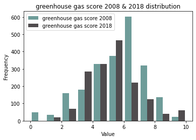

```python
n, bins, patches = plt.hist(x=[df08['greenhouse_gas_score'] , df18['greenhouse_gas_score']] ,
                            label=['greenhouse gas score 2008','greenhouse gas score 2018'],
                            bins=10, color = ['#31736e','#060003'],alpha=0.7, rwidth=0.85)
plt.legend()
plt.xlabel('Value')
plt.ylabel('Frequency')
plt.title('greenhouse gas score 2008 & 2018 distribution');
```

#### combined mpg distribution change

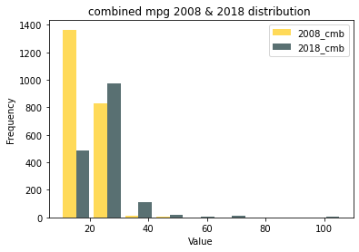

```python
n, bins, patches = plt.hist(x=[df08['cmb_mpg'] , df18['cmb_mpg'] ] , bins=9,
                            color=['#ffcb12' , '#133337' ], label=['2008_cmb' , '2018_cmb'] ,alpha=0.7, rwidth=0.85)
plt.legend()
plt.xlabel('Value')
plt.ylabel('Frequency')
plt.title('combined mpg 2008 & 2018 distribution ');
```

#### displacement and combined mpg correlation

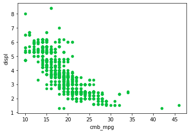

```python
# for 2008
df08.plot(x='cmb_mpg'  ,y= 'displ' , kind='scatter', color = '#03c03c' );
```

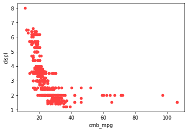

```python
# for 2018
df18.plot(x='cmb_mpg'  ,y= 'displ' , kind='scatter', color = '#ff4040' );
```

#### greenhouse gas score and combined mpg correlation

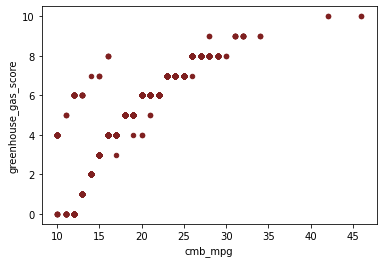

```python
# for 2008
df08.plot(x='cmb_mpg'  ,y= 'greenhouse_gas_score' , kind='scatter' , color = '#7f2020');
```

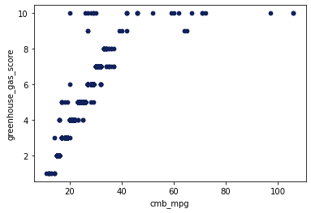

```python
# for 2018
df18.plot(x='cmb_mpg'  ,y= 'greenhouse_gas_score' , kind='scatter' , color = '#11215b');
```

#### the features relations

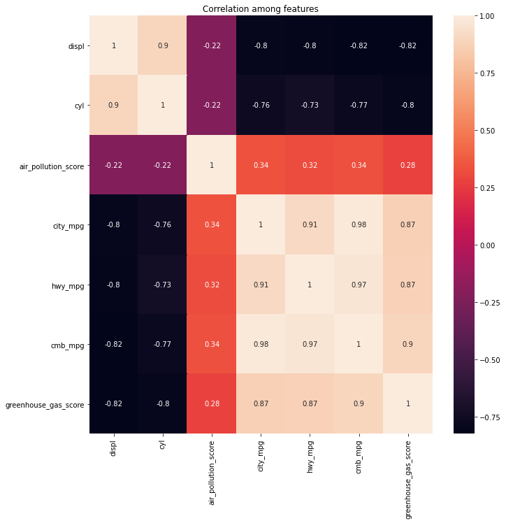

```python
# for 2008
Correlation_Matrix = df08.corr()
f, ax = plt.subplots(figsize=(11, 11))
sns.heatmap(Correlation_Matrix,annot=True)
plt.title('Correlation among features');
plt.show()
```

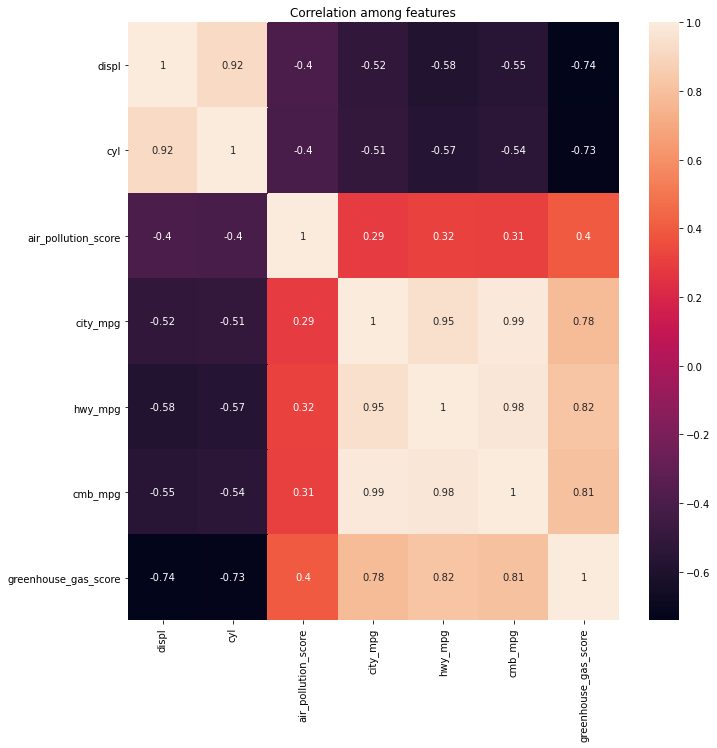

```python
# for 2018
Correlation_Matrix = df18.corr()
f, ax = plt.subplots(figsize=(11, 11))
sns.heatmap(Correlation_Matrix,annot=True)
plt.title('Correlation among features');
plt.show()
```

```python
# Saving the final CLEAN datasets as new files!
df08.to_csv('clean_fuel_08.csv', index=False)
df18.to_csv('clean_fuel_18.csv', index=False)
```